# Fooling Around with Word Embeddings

## /usr/share/dict/words

There's a file on Unix-like systems called [`words`](https://en.wikipedia.org/wiki/Words_%28Unix%29) which is a big list of words.

Let's see how many words it contains, and look at some examples from the beginning and end:

```python
!wc -l /usr/share/dict/words
!head /usr/share/dict/words
!tail /usr/share/dict/words
```

```
  235886 /usr/share/dict/words
A
a
aa
aal
aalii
aam
Aani
aardvark
aardwolf
Aaron
zymotoxic
zymurgy
Zyrenian
Zyrian
Zyryan
zythem
Zythia
zythum
Zyzomys
Zyzzogeton
```

Having a list of most English words sitting on your computer is useful!

Often my mom calls me on Sundays to tell me the weekly National Public Radio Puzzle—almost always a word puzzle—and often I can solve it with a quick script using the `words` file.

## /usr/share/dict/vectors (should be a thing)

It would be even cooler if there was a file that not only let your computer know what words exist, but also what they mean.

If you download some **word embeddings** then you'll have that magical file.

They're a way of turning words into numerical vectors, which can be useful because computers are often better at numbers than words.

Two recent popular word embeddings are **word2vec** and **GloVe** (Global Vectors).

The vectors are determined in completely different ways, but end up behaving very similarly, so for this thing I downloaded some GloVe vectors.

Let's see how many words it contains, and what some look like:

```python
!wc -l glove.6B/glove.6B.300d.txt
!head glove.6B/glove.6B.300d.txt | cut -c -100
!tail glove.6B/glove.6B.300d.txt | cut -c -100
```

```
  400000 glove.6B/glove.6B.300d.txt
the 0.04656 0.21318 -0.0074364 -0.45854 -0.035639 0.23643 -0.28836 0.21521 -0.13486 -1.6413 -0.26091
, -0.25539 -0.25723 0.13169 -0.042688 0.21817 -0.022702 -0.17854 0.10756 0.058936 -1.3854 0.58509 0.
. -0.12559 0.01363 0.10306 -0.10123 0.098128 0.13627 -0.10721 0.23697 0.3287 -1.6785 0.22393 0.12409
of -0.076947 -0.021211 0.21271 -0.72232 -0.13988 -0.12234 -0.17521 0.12137 -0.070866 -1.5721 -0.2246
to -0.25756 -0.057132 -0.6719 -0.38082 -0.36421 -0.082155 -0.010955 -0.082047 0.46056 -1.8477 -0.112
and 0.038466 -0.039792 0.082747 -0.38923 -0.21431 0.1702 -0.025657 0.09578 0.2386 -1.6342 0.14332 -0
in -0.44399 0.12817 -0.25247 -0.18582 -0.16614 0.25909 -0.22678 -0.069229 -0.077204 -1.5814 0.10753
a -0.29712 0.094049 -0.096662 -0.344 -0.18483 -0.12329 -0.11656 -0.099692 0.17265 -1.6386 0.1022 0.0
" 0.6947 0.22184 0.10526 0.012382 -0.2558 -0.32645 -0.48287 0.51755 -0.0872 -2.0289 0.35021 0.045363
's -0.001272 0.36514 -0.077363 -0.26559 0.17987 0.15347 -0.15338 0.43267 -0.13364 -1.716 0.069153 -0
sigarms 0.14649 -0.47266 0.17144 0.26431 -0.13895 -0.20788 0.41624 0.078204 0.10015 1.1079 0.18251 -
katuna -0.030013 0.24626 0.068192 0.089033 -0.19977 -0.92317 0.41307 -0.49583 0.4965 0.38058 -0.4684
aqm 0.46348 -0.42811 0.4575 0.25317 0.58327 -0.3598 0.36049 -0.16522 -0.27769 0.52559 -0.083879 -0.0
1.3775 0.71376 -0.56625 -0.18468 0.30104 -0.56443 -0.0068945 -0.31358 -0.35351 0.40245 0.90999 -0.43
corythosaurus 0.88649 -0.095745 0.18961 0.012919 -0.40925 -0.17462 0.20691 0.038473 0.041227 0.7609
chanty 0.3927 -0.022505 0.30458 0.18799 0.14118 0.72403 -0.25781 -0.13729 -0.016521 0.59596 -0.11014
kronik 0.13679 -0.13909 -0.36089 0.079864 0.32149 0.26387 -0.1099 0.04442 0.083869 0.79133 0.33604 -
rolonda 0.075713 -0.040502 0.18345 0.5123 -0.22856 0.83911 0.17878 -0.71301 0.3269 0.69535 0.19446 -
zsombor 0.81451 -0.36221 0.31186 0.81381 0.18852 -0.3136 0.82784 0.29656 -0.085519 0.47597 0.23528 0
sandberger 0.429191 -0.296897 0.15011 0.245201 -0.00352027 -0.0576971 0.1409 -0.222294 0.221153 0.76
```

So it's a lot like `/usr/share/dict/words` except that every word is followed by 300 numbers.

We can load all of these vectors into memory like so:

```python
import numpy as np
from tqdm import tqdm

vectors = {}
with open('glove.6B/glove.6B.300d.txt') as f:
    for line in tqdm(f, total=400000):
        word, vector = line.split(maxsplit=1)
        v = np.fromstring(vector, sep=' ', dtype='float32')
        vectors[word] = v / np.linalg.norm(v)
```

## Example

Let's see what a vector looks like. Every word is represented as 300 numbers:

```python
vectors['kitten']
```

```
array([-0.03189607,  0.00502735, -0.03142706, -0.09080496, -0.01372096,
       -0.00790456,  0.030317  , -0.07247453, -0.04573111,  0.05332294,
        0.07288674, -0.08122185,  0.00484673, -0.01537791,  0.06188687,
        0.03534793, -0.04661558, -0.01694448, -0.04042754,  0.00050012,
        0.03243811,  0.11682782, -0.02655192,  0.06118741, -0.07047677,
       -0.0037469 ,  0.02992264,  0.03477181,  0.02501019,  0.01804155,
       -0.05208955, -0.09751231, -0.03454461, -0.04255676,  0.07700237,
        0.04495537, -0.05921724,  0.01425699,  0.00727082,  0.08407649,
        0.00414386,  0.0257486 ,  0.0416804 , -0.09127396, -0.06493788,
       -0.01052713,  0.11504428, -0.04301928, -0.04149053, -0.01986242,
       -0.05381305, -0.05122618,  0.00951202,  0.07270174,  0.015696  ,
       -0.00185138, -0.02895541,  0.10035073, -0.01022527, -0.03901888,
       -0.0286357 , -0.00038816, -0.06632058,  0.00219413,  0.04281642,
       -0.10785005,  0.11508809, -0.01601003, -0.01545094, -0.02594334,
       -0.06376292,  0.05213661, -0.10611357, -0.01170696,  0.03170781,
        0.09749608,  0.04564185,  0.03465658,  0.03528626, -0.01317632,
       -0.0658402 ,  0.06708658,  0.02708261, -0.00941676,  0.05004472,
       -0.09964802, -0.06706873,  0.09575149,  0.03073084, -0.0779128 ,
       -0.10904612, -0.00137211,  0.01427436,  0.03249491, -0.08582757,
       -0.06214815,  0.04685901, -0.01529872, -0.02868276, -0.03035758,
        0.01193076,  0.03669654, -0.02238437, -0.00971942, -0.02112015,
       -0.12391331, -0.02551491, -0.02295725, -0.06453866, -0.01971311,
        0.10288567,  0.11489497, -0.0503693 ,  0.0644429 ,  0.02602124,
        0.08316119,  0.08443028,  0.01934309,  0.01912725, -0.03951548,
       -0.05975765,  0.00633588,  0.05523144,  0.10743134,  0.02565285,
        0.0591085 , -0.06582073,  0.01399035,  0.02120291, -0.05888617,
        0.10206449, -0.09069946, -0.0107618 ,  0.10852517, -0.04826605,
       -0.0140061 , -0.02386281, -0.0154154 , -0.08144581, -0.06050904,
        0.09513642, -0.07653173, -0.07035505, -0.06641957,  0.0959511 ,
        0.00210147, -0.0283728 ,  0.0251952 ,  0.02327858,  0.0516822 ,
       -0.06586941,  0.12737978, -0.0497526 ,  0.09444507,  0.02383198,
        0.07142615,  0.00255052, -0.05192077, -0.00423393,  0.09097698,
        0.00370179, -0.09085364, -0.05976252, -0.00505705, -0.03072597,
       -0.01971474,  0.07135637,  0.03769137,  0.0279054 , -0.03008169,
       -0.06055124,  0.03197396, -0.06527382,  0.07851813,  0.00572016,
       -0.0784516 ,  0.02748995, -0.04415205,  0.0130929 , -0.01004708,
        0.08195702, -0.05701986, -0.00528685, -0.02261969, -0.01347201,
       -0.05679915,  0.13558668, -0.04854032,  0.11129056, -0.06001731,
        0.02259372, -0.09510072, -0.0601017 , -0.07179942, -0.13283914,
        0.04055088, -0.04183944, -0.0511499 ,  0.03285681,  0.05362966,
        0.10976992,  0.04941829,  0.06698109,  0.05332943,  0.01387919,
        0.07408281, -0.04666426,  0.00355118, -0.00381263,  0.04533675,
       -0.03874948,  0.07053033, -0.02114125,  0.08540725,  0.00161824,
        0.00835036, -0.01319466, -0.04281155, -0.00771225, -0.00845244,
       -0.10540923,  0.0800761 , -0.05904034,  0.01925546, -0.05956128,
       -0.02953153,  0.08487982, -0.02554736, -0.04823359, -0.0664569 ,
        0.05329373, -0.06990552, -0.03302883, -0.02510107, -0.00953555,
        0.02697387, -0.02970518,  0.01658745, -0.04818328, -0.03224336,
        0.074706  , -0.08186127, -0.09457977,  0.06484376, -0.00644494,
        0.02794598,  0.00331457, -0.02484141, -0.04680546,  0.05409705,
       -0.11592874,  0.02648376, -0.01906234,  0.00095768, -0.02165894,
       -0.05348847,  0.05069712, -0.03122906,  0.01530424, -0.03511424,
        0.02661684,  0.02367618,  0.03573255, -0.01845538, -0.05866708,
       -0.01240951, -0.01477177, -0.06186577,  0.0008141 ,  0.05032061,
       -0.12011739, -0.09979408, -0.10374416, -0.12338588, -0.09950358,
        0.04013867,  0.0424464 ,  0.04548768, -0.10236635,  0.08622194,
       -0.0280823 ,  0.14800008, -0.03903186, -0.0107777 , -0.07649115,
       -0.03742846,  0.03051662,  0.01065777, -0.07335252, -0.10409634,
       -0.03014498,  0.06561625,  0.07241936, -0.01217062,  0.00568624,
       -0.02907225,  0.05303569,  0.01673026,  0.08879907, -0.02625818], dtype=float32)
```

## Plotting in 2 dimensions

Of course, we can't see 300 dimensions, so let's plot some words in 2 dimensions, squashing them down from 300 using **PCA** (Principal Component Analysis):

```python
import matplotlib.pyplot as plt
from sklearn.decomposition import PCA

%matplotlib inline
plt.rcParams["figure.figsize"] = (18, 10)

def plot_words(*words, lines=False):
    pca = PCA(n_components=2)
    xys = pca.fit_transform([vectors[w] for w in words])

    if lines:
        for i in range(0, len(words), 2):
            plt.plot(xys[i:i+2, 0], xys[i:i+2, 1])
    else:
        plt.scatter(*xys.T)

    for word, xy in zip(words, xys):
        plt.annotate(word, xy, fontsize=20)

    return pca
```

When we plot the words, we'll see that similar words end up in similar locations, so that suggests the vectors have captured something about English, cool!

```
PCA(copy=True, n_components=2, whiten=False)
```

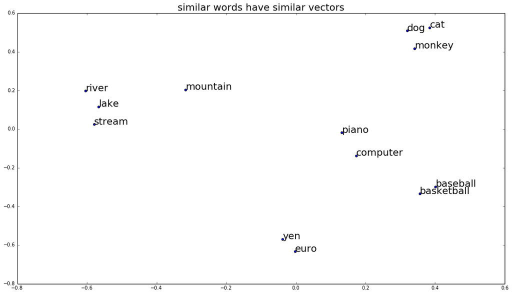

```python
plt.title('similar words have similar vectors', fontsize=20)

plot_words('stream', 'euro', 'baseball', 'mountain', 'computer', 'lake', 'yen',
           'monkey', 'dog', 'basketball', 'cat', 'river', 'piano')
```

## Similar words

We can search all of the vectors to find the most similar words to a given word. (A fun way to do this is using a heap.)

```python
import heapq

def most_similar(v, *ignore, N=1):
    similar = []
    for word, u in vectors.items():
        if word in ignore: continue
        similarity = u.dot(v)
        if len(similar) < N:
            heapq.heappush(similar, (similarity, word))
        else:
            heapq.heappushpop(similar, (similarity, word))
    return sorted(similar, reverse=True)
```

The 10 most similar words to "piano" seem pretty reasonable. The top word is of course "piano" itself:

```python
most_similar(vectors['piano'], N=10)
```

```
[(0.99999994, 'piano'),
 (0.81736529, 'violin'),
 (0.75439155, 'cello'),
 (0.71672165, 'guitar'),
 (0.66841698, 'concerto'),
 (0.64464086, 'clarinet'),
 (0.63440984, 'saxophone'),
 (0.63233328, 'pianist'),
 (0.6304934, 'harpsichord'),
 (0.62700754, 'orchestral')]
```

## Relationship vectors

Here's where things start to get interesting. Since every word is a vector, we can do things like add and subtract them.

If we subtract "france" from "paris", we now have a vector that sort of represents "capital of".

Here are a bunch of countries and capitals plotted in 2 dimensions. The vectors from each country to capital are all approximately the same "capital of" vector:

```
PCA(copy=True, n_components=2, whiten=False)
```

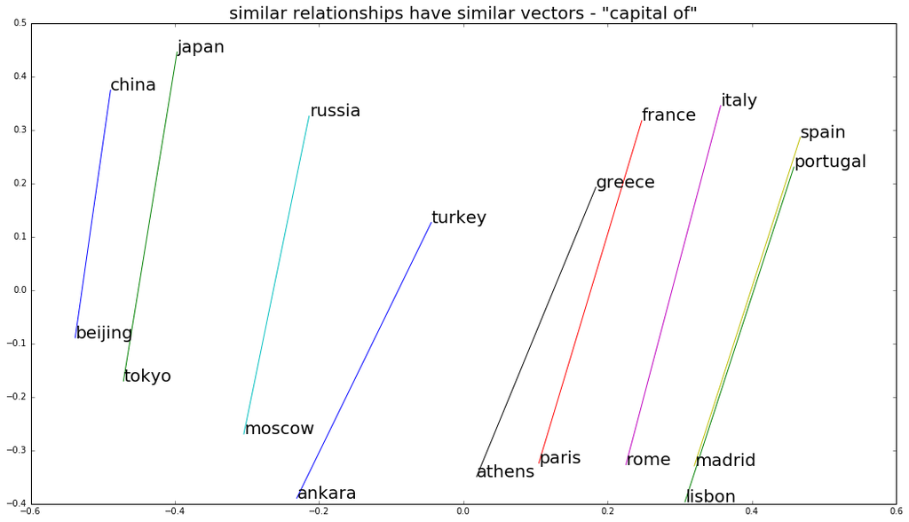

```python
plt.title('similar relationships have similar vectors - "capital of"', fontsize=20)

plot_words('china', 'beijing',
           'japan', 'tokyo',
           'france', 'paris',
           'russia', 'moscow',
           'italy', 'rome',
           'spain', 'madrid',
           'greece', 'athens',
           'turkey', 'ankara',
           'portugal', 'lisbon', lines=True)
```

We can see a similar consistency when visualizing the vector from a comparative adjective to its superlative:

```
PCA(copy=True, n_components=2, whiten=False)
```

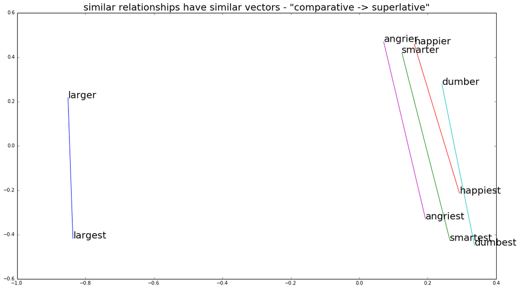

```python
plt.title('similar relationships have similar vectors - "comparative -> superlative"', fontsize=20)

plot_words('larger', 'largest',
           'smarter', 'smartest',
           'happier', 'happiest',
           'dumber', 'dumbest',
           'angrier', 'angriest', lines=True)
```

## Relationship vectors can solve analogies

Since the "capital of" vector seems to be so consistent, we could use it to find a capital we don't know.

Let's say we've forgotten what the capital of Poland is, but we remember that Paris is the capital of France.

Then we can just solve for `x = Paris - France + Poland`.

Sure enough, the most similar vector is `x ≈ Warsaw`!

```python
most_similar(vectors['paris'] - vectors['france'] + vectors['poland'])
```

```
[(0.85991102, 'warsaw')]
```

We can also visualize this vector arithmetic by taking the `Paris - France` vector and moving it over to `Poland`:

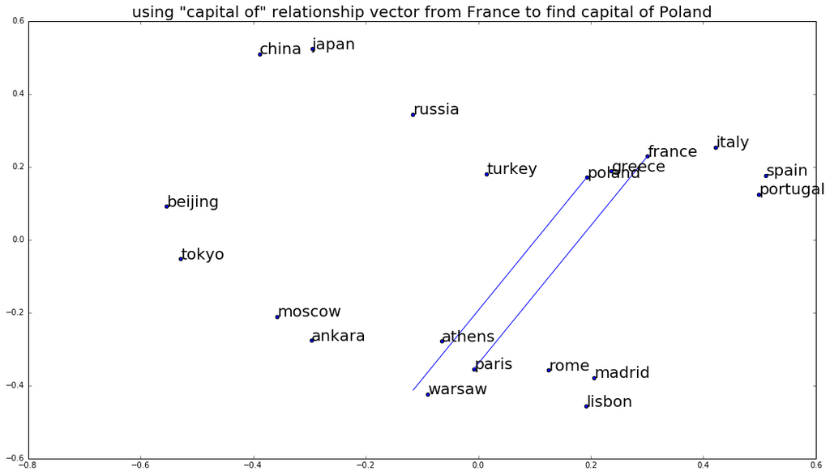

```python
plt.title('using "capital of" relationship vector from France to find capital of Poland', fontsize=20)

pca = plot_words('china', 'beijing',
                 'japan', 'tokyo',
                 'france', 'paris',
                 'russia', 'moscow',
                 'italy', 'rome',
                 'spain', 'madrid',
                 'greece', 'athens',
                 'turkey', 'ankara',
                 'portugal', 'lisbon',
                 'poland', 'warsaw')
paris, france, poland = pca.transform([vectors[x] for x in ('paris', 'france', 'poland')])
capital_of = paris - france

capital_of_france = capital_of + france
plt.plot([france[0], capital_of_france[0]], [france[1], capital_of_france[1]], 'b')

capital_of_poland = capital_of + poland
plt.plot([poland[0], capital_of_poland[0]], [poland[1], capital_of_poland[1]], 'b')
```

We can do the same thing to see that `Queen - Woman + Man ≈ King`:

```python
most_similar(vectors['queen'] - vectors['woman'] + vectors['man'], 'queen')
```

```
[(0.74458629, 'king')]
```

So if we let `Regal = Queen - Woman`, then `Regal + Man ≈ King`.

But vector addition is commutative, so it's equivalent to let `Masculine = Man - Woman`, and then `Masculine + Queen ≈ King`.

These are equivalent because by commutativity and associativity of vector addition:

```
Regal + Man = (Queen - Woman) + Man = (Man - Woman) + Queen = Masculine + Queen
```

…which you can visualize as the two ways of traversing the parallelogram in the below plot.

This is related to the concept of a "commutative diagram" in algebra:

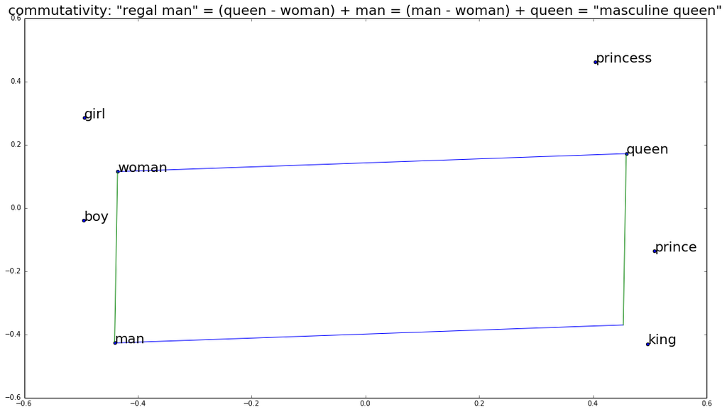

```python
plt.title('commutativity: "regal man" = (queen - woman) + man = (man - woman) + queen = "masculine queen"', fontsize=20)

pca = plot_words('man', 'king',
                 'woman', 'queen',
                 'boy', 'prince',
                 'girl', 'princess')
queen, woman, man = pca.transform([vectors[x] for x in ('queen', 'woman', 'man')])
regal = queen - woman
masculine = man - woman

regal_woman = regal + woman
plt.plot([woman[0], regal_woman[0]], [woman[1], regal_woman[1]], 'b')
masculine_woman = masculine + woman
plt.plot([woman[0], masculine_woman[0]], [woman[1], masculine_woman[1]], 'g')

regal_man = regal + man
plt.plot([man[0], regal_man[0]], [man[1], regal_man[1]], 'b')
masculine_queen = masculine + queen
plt.plot([queen[0], masculine_queen[0]], [queen[1], masculine_queen[1]], 'g')
```

Another example while we're at it, `Kitten - Cat + Dog ≈ Puppy`:

```python
most_similar(vectors['kitten'] - vectors['cat'] + vectors['dog'], 'kitten')
```

```
[(0.73260075, 'puppy')]
```

## What are the 300 dimensions?

Does each of the 300 dimensions correspond to some human-friendly spectrum, such as "big <-> small" or "dark <-> light"?

We can look at example words which are evenly spaced along a dimension, but it usually ends up being pretty hard to tell what the dimension "means", for me at least.

It looks like dimension #2 is kind of like "traditional <-> modern"? But it's a bit of a stretch:

```python
import itertools as it

N = 10000
top_vectors = {}
with open('glove.6B/glove.6B.50d.txt') as f:
    for line in tqdm(it.islice(f, N), total=N):
        word, vector = line.split(maxsplit=1)
        v = np.fromstring(vector, sep=' ', dtype='float32')
        top_vectors[word] = v / np.linalg.norm(v)

def print_dimension_examples(i, N=10):
    xs = {w: v[i] for w, v in top_vectors.items()}
    for x in np.linspace(min(xs.values()), max(xs.values()), N):
        print(*min(xs.items(), key=lambda w_x: abs(x - w_x[1])))
```

```python
print_dimension_examples(2, N=10)
```

```
ritual -0.473578
victorian -0.373939
influences -0.27019
examination -0.168541
created -0.066805
republics 0.0348972
interstate 0.136595
numbers 0.238045
x 0.339924
plug 0.441698
```